# Bayesian data analysis & cognitive modeling

\[ \definecolor{firebrick}{RGB}{178,34,34} \newcommand{\red}[1]{{\color{firebrick}{#1}}} \] \[ \definecolor{mygray}{RGB}{178,34,34} \newcommand{\mygray}[1]{{\color{mygray}{#1}}} \] \[ \newcommand{\set}[1]{\{#1\}} \] \[ \newcommand{\tuple}[1]{\langle#1\rangle} \] \[\newcommand{\States}{{T}}\] \[\newcommand{\state}{{t}}\] \[\newcommand{\pow}[1]{{\mathcal{P}(#1)}}\]

## introduction

## 3 pillars of BDA (recap)

parameter estimation:

\[\underbrace{P(\theta \, | \, D)}_{posterior} \propto \underbrace{P(\theta)}_{prior} \ \underbrace{P(D \, | \, \theta)}_{likelihood}\]

model comparison

\[\underbrace{\frac{P(M_1 \mid D)}{P(M_2 \mid D)}}_{\text{posterior odds}} = \underbrace{\frac{P(D \mid M_1)}{P(D \mid M_2)}}_{\text{Bayes factor}} \ \underbrace{\frac{P(M_1)}{P(M_2)}}_{\text{prior odds}}\]

prediction

prior predictive

\[ P(D) = \int P(\theta) \ P(D \mid \theta) \ \text{d}\theta \]

posterior predictive

\[ P(D \mid D') = \int P(\theta \mid D') \ P(D \mid \theta) \ \text{d}\theta \]

## why model predictions?

1. model-based beliefs about what is likely to happen
   - practical decision making
2. model comparison
   - information criteria
   - Bayes factor
3. model criticism
   - is the model any good?
   - given belief in the model, should we be shocked by this new observation?

     [ \(p\)-values ]

## overview

|  | estimation | comparison | criticism |
| --- | --- | --- | --- |
| goal | which \(\theta\), given \(M\) & \(D\)? | which better: \(M_0\) or \(M_1\)? | \(M\) good model of \(D\)? |
| method | Bayes rule | Bayes factor | \(p\)-value |
| no. of models | 1 | 2 | 1 |
| \(H_0\) | subset of \(\theta\) | \(P(\theta \mid M_0), P(D \mid \theta, M_0)\) | \(P(\theta), P(D \mid \theta)\) |
| \(H_1\) | — | \(P(\theta \mid M_1), P(D \mid \theta, M_1)\) | — |
| prerequisites | \(P(\theta), \alpha \times P(D \mid \theta)\) | — | test statistic |
| pros | lean, easy | intuitive, plausible, Ockham's razor | absolute |
| cons | vagueness in ROPE | prior dependence, computational load | sample space? |

## road map for today

NHST

- inference, HDIs & ROPEs
- nested model comparison
- \(p\)-values

model criticism

- posterior predictive checks
- prior/posterior \(p\)-values

## testing a null

## up next

compare 3 methods for testing a null hypothesis:

1. \(p\)-values
2. parameter inference with ROPEs
3. nested model comparison

running example:

\(k=7\), \(N=24\) \(\rightarrow\) \(\theta = 0.5?\)

[figure not shown]

## definition \(p\)-value

in the general case, the \(p\)-value of observation \(x\) under null hypothesis \(H_0\), with sample space \(X\), sampling distribution \(P(\cdot \mid H_0) \in \Delta(X)\) and test statistic \(t \colon X \rightarrow \mathbb{R}\) is:

\[ p(x ; H_0, X, P(\cdot \mid H_0), t) = \int_{\left\{ \tilde{x} \in X \ \mid \ t(\tilde{x}) \ge t(x) \right\}} P(\tilde{x} \mid H_0) \ \text{d}\tilde{x}\]

intuitive slogan: probability of at least as extreme outcomes

for an exact test we get:

\[ p(x ; H_0, X, P(\cdot \mid H_0)) = \int_{\left\{ \tilde{x} \in X \ \mid \ P(\tilde{x} \mid H_0) \le P(x \mid H_0) \right\}} P(\tilde{x} \mid H_0) \ \text{d}\tilde{x}\]

intuitive slogan: probability of at least as unlikely outcomes

notation: \(\Delta(X)\) – set of all probability measures over \(X\)

## NHST by \(p\)-value

- data: we flip \(n=24\) times and observe \(k = 7\) successes
- null hypothesis: \(\theta = 0.5\)
- sampling distribution: binomial distribution

\[ B(k ; n = 24, \theta = 0.5) = \binom{n}{k} \theta^{k} \, (1-\theta)^{n-k} \]

```r
binom.test(7,24)$p.value
```

```
## [1] 0.06391466
```

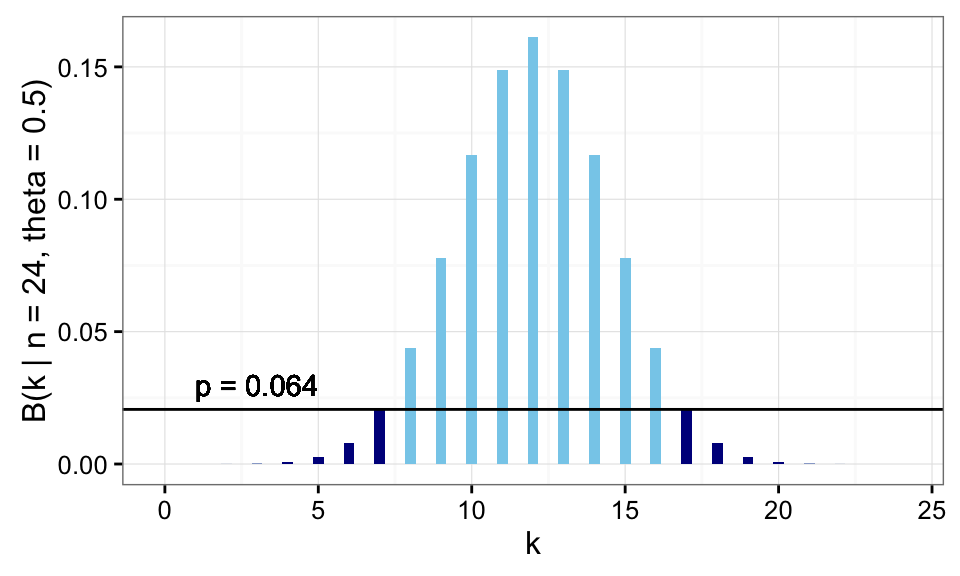

## posterior inference

- observed: \(k = 7\) out of \(N = 24\) flips came up heads
- goal: estimate \(P(\theta \mid D)\) & determine posterior 95% HDI

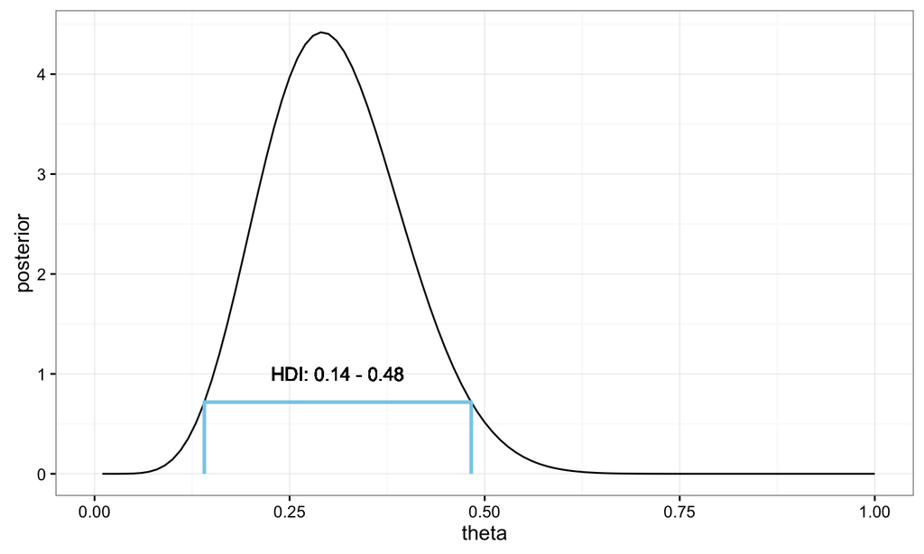

## ROPEs and credible values

regions of practical equivalence

- small regions \([\theta - \epsilon, \theta + \epsilon]\) around each \(\theta\)
  - values (practically) indistinguishable from \(\theta\)

credible values

- value \(\theta\) is rejectable if its ROPE lies entirely outside of posterior HDI
- value \(\theta\) is believable if its ROPE lies entirely whithin posterior HDI

NHST by ROPE for our example

\(\theta = 0.5\) is rejectable for all ROPEs with ca. \(\epsilon \le 0.02\)

## Bayes factors for NHST

- \(M_0\): \(\theta = 0.5\) & \(k \sim \text{Binomial}(0.5, N)\)
- \(M_1\): \(\theta \sim \text{Beta}(1,1)\) & \(k \sim \text{Binomial}(\theta, N)\)

straightforward

\[ \begin{align*} \text{BF}(M_0 > M_1) & = \frac{P(D \mid M_0)}{P(D \mid M_1)} \\ & = \frac{{{N}\choose{k}} 0.5^{k} \, (1-0.5)^{N - k}}{\int_0^1 {{N}\choose{k}} \theta^{k} \, (1-\theta)^{N - k} \text{ d}\theta} \\ & \approx 0.516 \end{align*} \]

Savage-Dickey

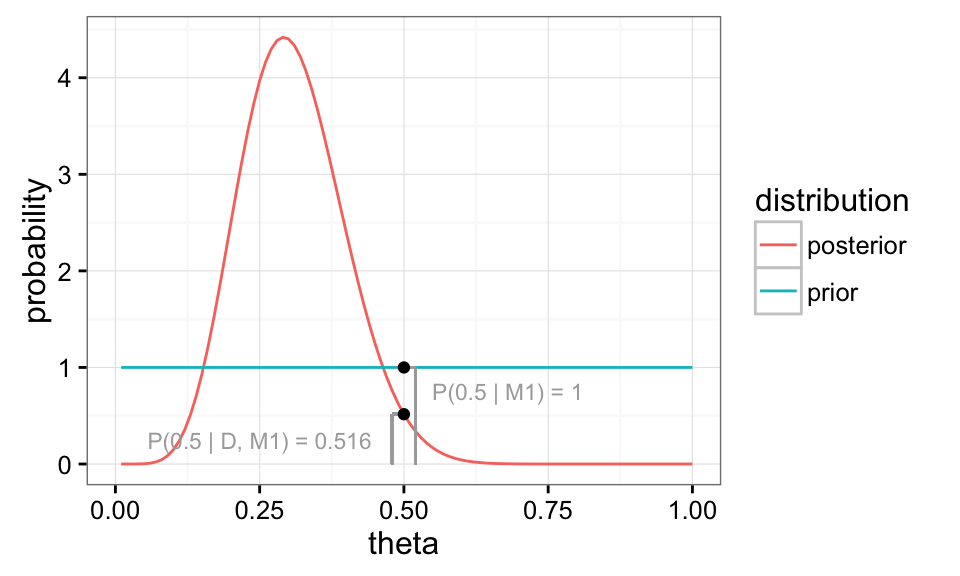

## summary

[output not shown]

## comparison

## Jeffreys-Lindley paradox

"paradox": two established methods give contradictory results

```r
k = 49581
N = 98451
```

\(p\)-value NHST

```r
binom.test(k, N)$p.value
```

```
## [1] 0.02364686
```

reject \(H_0\)

Savage-Dickey BF

```r
dbeta(0.5, k+1, N - k + 1)
```

```
## [1] 19.21139
```

strong evidence in favor of \(H_0\)

## simulation

- let the true bias be \(\theta = 0.5\)
- generate all possible outcomes \(k\) keeping \(N\) fixed
  - \(N \in \{ 10, 100, 1000, 10000, 100000 \}\)
  - true frequency of \(k\) is \(Binomial(k \mid N, \theta = 0.5)\)
- look at the frequency of test results, coded thus:

|  | estimation | comparison | criticism |
| --- | --- | --- | --- |
| \(M_0\) | \([.5-\epsilon, 0.5+\epsilon] \sqsubseteq\) 95% HDI or v.v. | BF(\(M_0\)>\(M_1\)) > 6 | \(p\) > 0.05 |
| \(M_1\) | \([.5-\epsilon, 0.5+\epsilon] \, \cap \,\) 95% HDI \(=\emptyset\) | BF(\(M_1\)>\(M_0\)) > 6 | \(p\) <= 0.05 |
| ?? | otherwise | otherwise | never |

(more on this [here](http://michael-franke.github.io/statistics/2016/09/30/Comparison_binomial.html))

## results

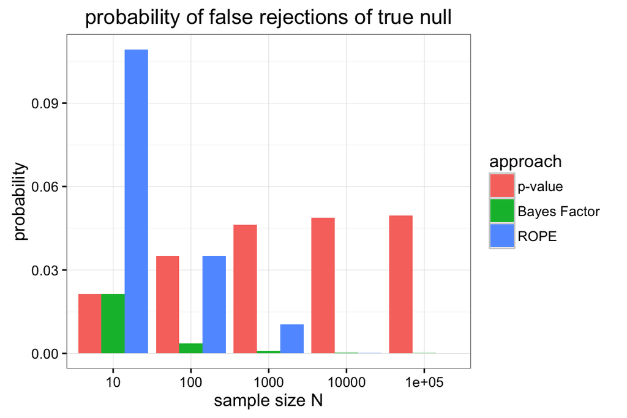

BF selects \(H_0\) correctly with prob. 0.986 for \(N = 10000\), and with 0.996 for \(N = 100000\).

[c.f., Lindley's solution to 'paradox': adjust \(p\) depending on \(N\); similar for ROPE's \(\epsilon\)]

## model criticism

## motivation

- parameter estimation: what \(\theta\) to believe in?
- model comparison: which model is better than another?
- model criticism: is a given model plausible (enough)?

posterior predictive checks

graphically compare simulated observations with actual observation

Bayesian predictive \(p\)-values

measure surprise level of data under a model

[think: \(p\)-value for a non-trivial, serious model with potential uncertainty about parameters]

## posterior predictive checks

exponential forgetting model

```r
y = c(.94, .77, .40, .26, .24, .16)
t = c(  1,   3,   6,   9,  12,  18)
obs = y*100
```

```r
model{
  a ~ dunif(0,1.5)
  b ~ dunif(0,1.5)
  for (i in 1: 6){
    p[i] = min(max( a*exp(-t[i]*b), 0.0001), 0.9999)
    obs[i] ~ dbinom(p[i], 100)    # condition on data
    obsRep[i] ~ dbinom(p[i], 100) # replicate fake data
  }
}
```

## PPC: exponential model

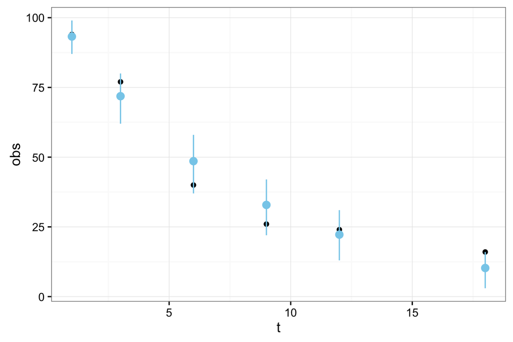

- black dots: data
- blue dots: mean of replicated fake data
- blue bars: 95% HDIs of replicated fake data

## PPC: power model

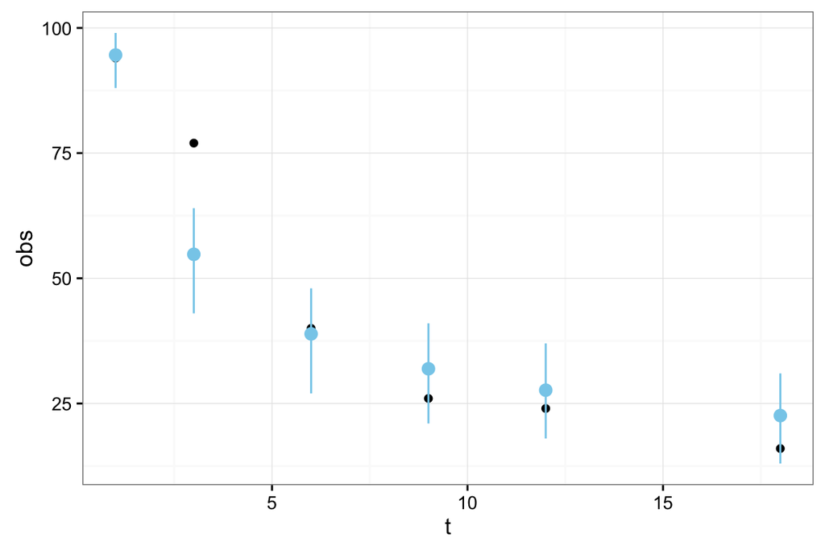

- black dots: data
- blue dots: mean of replicated fake data
- blue bars: 95% HDIs of replicated fake data

## Bayesian predictive model criticism

- fix a data set \(x\) from a set of possible observations \(X\)
- fix a model \(M\) with \(P(\theta)\) and \(P(X = x \mid \theta)\)
  - NB: \(P(\theta)\) can be conditioned on data: prior/posterior predictive \(p\)-value
- fix a test statistic \(t \colon X, \theta \rightarrow \mathbb{R}\)
  - test statistic may depend on parameters
- Bayesian predictive \(p\)-value:

\[ p(x ; X, M = \tuple{P(\theta), P(x\mid\theta)}, t) = \int_{\left\{ \tilde{x} \in X \ \mid \ t(\tilde{x},\theta) \ge t(x, \theta) \right\}} \int P(\tilde{x} \mid \theta) P(\theta) \ \text{d}\theta \ \text{d}\tilde{x}\]

- compare to standard \(p\)-value definition:

\[ p(x ; H_0, X, P(\cdot \mid H_0), t) = \int_{\left\{ \tilde{x} \in X \ \mid \ t(\tilde{x}) \ge t(x) \right\}} P(\tilde{x} \mid H_0) \ \text{d}\tilde{x}\]

## example

```r
obs = c(1, 1, 0, 0, 0, 0, 0, 1, 1, 1, 1, 1, 0, 0, 0, 0, 0, 0, 0, 0)
k = sum(obs) # 7
N = length(obs) #20
```

\(p\)-value NHST:

- do not reject NH \(\theta = 0.5\)

```r
binom.test(k, N, 0.5)$p.value
```

```
## [1] 0.263176
```

Bayesian posterior predictive \(p\)-value

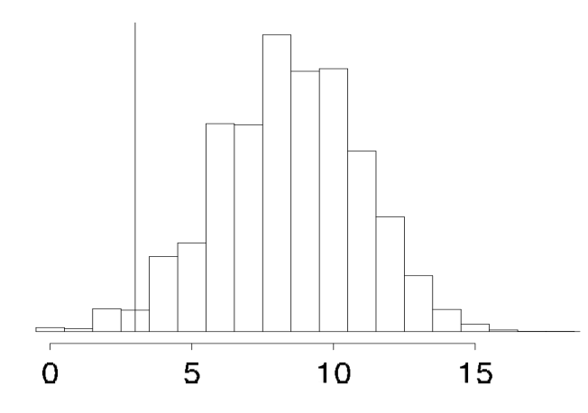

Gelman et al. 2014, p.147–8

## summary

## summary

|  | estimation | comparison | criticism |
| --- | --- | --- | --- |
| goal | which \(\theta\), given \(M\) & \(D\)? | which better: \(M_0\) or \(M_1\)? | \(M\) good model of \(D\)? |
| method | Bayes rule | Bayes factor | \(p\)-value |
| no. of models | 1 | 2 | 1 |
| \(H_0\) | subset of \(\theta\) | \(P(\theta \mid M_0), P(D \mid \theta, M_0)\) | \(P(\theta), P(D \mid \theta)\) |
| \(H_1\) | — | \(P(\theta \mid M_1), P(D \mid \theta, M_1)\) | — |
| prerequisites | \(P(\theta), \alpha \times P(D \mid \theta)\) | — | test statistic |
| pros | lean, easy | intuitive, plausible, Ockham's razor | absolute |
| cons | vagueness in ROPE | prior dependence, computational load | sample space? |

## outlook

Friday

- bootcampling GCM (Lee & Wagenmakers ch. 17)

Tuesday

- introduction to Stan